## Front Matter

I want the Notebook to be as informative as possible, but model creating and training process follows some standard procedure that I do not want to repeat. Therefore, if you can, spend time reading the `PROLOGUE/Routine.ipynb` Notebook first.

# Paper Implementation - VGG16

Hello, this is my first milestone project - implementation of the VGG16 architecture from the paper ["Very Deep Convolutional Networks for Large-Scale Image Recognition"](https://arxiv.org/abs/1409.1556). The paper explored the effect of increasing layers on a model based on the filter size of $3*3$ that we previously explored in the `TinyCNN` notebook (that is also the reason why that architecture is called TinyVGG). The architecture was the runner-up in the ImageNet 2014 Challenge for classification.

16 in VGG16 stands for 16 layers, all based on two basic units: convolution with filter size $3*3$, stride $1$, padding $1$ and max-pooling with window size $2*2$, stride $2$. The table shown below, taken from the paper abovem, is the architecture for each of the VGG configuration. In this project, I will implement the VGG16-D one.

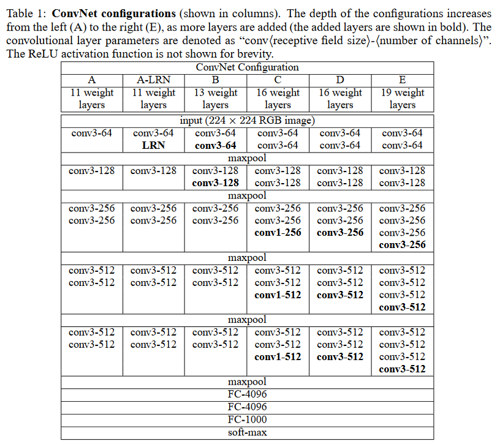

I divide the project into two notebooks. This is the first one, where I will focus on acquiring and transforming the data. The next one will be about building and training the model.

## Downloading and extracting data

The task for our model will be classification, using a bigger dataset called [Food101](https://pytorch.org/vision/main/generated/torchvision.datasets.Food101.html). This is a built-in PyTorch dataset, so the processing can be fairly straightforward. However, it is not fun, so let's take the [Kaggle version](https://www.kaggle.com/datasets/kmader/food41) and process it to what we want.

First, downloading data from Kaggle. The easy way: you can download the zip file (~6 GB), upload it to Google Drive, and then mount Google Drive to Colab. The slightly harder approach: you will need to sign up and obtain a Kaggle token, and then use the `kaggle` module to download the data. Let's do that.

First, we need a variable to keep track of the environment we are in as it is different to run the notebook right on Kaggle and run it anywhere else (from the teaching of a Kaggle Grandmaster)

```python
# Import modules
import os
from pathlib import Path

# Keep an environment variable
iskaggle = os.environ.get('KAGGLE_KERNEL_RUN_TYPE', '')
```

Next, based on the [docs](https://github.com/Kaggle/kaggle-api), we will need to create a `/.kaggle/kaggle.json`. You can go to File Explorer and create a folder in your machine, or we can create that file right from the notebook. Let's do that.

```python
creds = '{"username":"hangenyuu","key":"a34fdad4d3f3d0ee2b1b7a010b3ffc4c"}'
```

```python
# Paste your API here (I have run and then deleted mine)
# creds = ''
```

```python
cred_path = Path('~/.kaggle/kaggle.json').expanduser()
if not cred_path.exists():
    cred_path.parent.mkdir(exist_ok=True)
    cred_path.write_text(creds)
    cred_path.chmod(0o600)
```

Next, let's use the method `dataset_download_cli` to download and unzip data files.

```python
# Sanity check
!kaggle datasets list
```

[output not shown]

```python
path = Path('kmader/food41')
```

```python
if not iskaggle and not path.exists():
    import kaggle
    kaggle.api.dataset_download_cli(str(path))
```

```
Downloading food41.zip to /content
```

We have the data in the zip file. Now all we need to do is to extract them out.

```python
folder_path = Path('food41')
os.mkdir(folder_path)
```

```python
import zipfile
zipfile.ZipFile(f'{folder_path}.zip').extractall(folder_path)
```

## Food-101

The dataset is introduced in this [paper](https://data.vision.ee.ethz.ch/cvl/datasets_extra/food-101/ttps://), consisting of 101 classes, each with 750 training and 250 testing examples, totalling 1000 images each. The dataset comes with a metadata folder, giving information about which image should go into which subset, which is great! The data was already split into traing and testing examples, but we also need a *validation set*. The testing examples were manually selected to contain noise and challenge the model, so we will not touch that, but we will split the training set further to create a validation set. Now, creating a good validation set is [an art](https://www.fast.ai/posts/2017-11-13-validation-sets.html), but here we will jsut use good ol' random splitting.

First, we will need to format the in the `images` folder into `train`, `valid`, and `test` folders. Next, we will load the data. The process is quite the same, what's new this time is we will apply more transformation.

```python
# Generic torch process
from torch import nn
import torch
from torch.utils.data import DataLoader

# Specifically for computer vision
import torchvision
from torchvision import datasets, transforms

# Other module(s)
import matplotlib.pyplot as plt
import gc
import json
import shutil
from sklearn.model_selection import train_test_split
import numpy as np
```

```python
np.random.seed(17)
torch.manual_seed(17)
```

```
<torch._C.Generator at 0x7fadaaccae90>
```

```python
with open('/content/food41/meta/meta/train.json', 'r') as fp:
    train_dict = json.load(fp)
with open('/content/food41/meta/meta/test.json', 'r') as fp:
    test_dict = json.load(fp)
print(len(train_dict['apple_pie']), train_dict['apple_pie'][-10:])
print(len(test_dict['apple_pie']), test_dict['apple_pie'][-10:])
```

```
750 ['apple_pie/960233', 'apple_pie/960669', 'apple_pie/962315', 'apple_pie/966595', 'apple_pie/973088', 'apple_pie/973428', 'apple_pie/98352', 'apple_pie/98449', 'apple_pie/987860', 'apple_pie/997124']
250 ['apple_pie/885848', 'apple_pie/886793', 'apple_pie/904832', 'apple_pie/908367', 'apple_pie/963140', 'apple_pie/981895', 'apple_pie/984571', 'apple_pie/986844', 'apple_pie/99556', 'apple_pie/997950']
```

As mentioned, there are 1000 images for 101 categories of food. Each .json file is essentially a dictionary containing 101 keys and 101 values, each value is a list of paths of 750 training images or 250 testing images.

The list value of a dictionary key contains the strings that are the file paths of the images without the extension. We will note this while using it to copy the images to proper folders.

```python
if not os.path.exists('data'):
    os.mkdir('data')
new_data_path = Path('data')
original_data_path = Path('food41/images')
new_folders = ['train', 'test']
for folder in new_folders:
    if not os.path.exists(new_data_path/folder):
        os.mkdir(new_data_path/folder)
    if folder == 'train':
        if not os.path.exists(new_data_path/'valid'):
            os.mkdir(new_data_path/'valid')
        for key, value in train_dict.items():
            train_value, valid_value = train_test_split(value, train_size=0.75)
            train_set, valid_set = set(train_value), set(valid_value)
            if not os.path.exists(new_data_path/folder/key):
                os.mkdir(new_data_path/folder/key)
            if not os.path.exists(new_data_path/'valid'/key):
                os.mkdir(new_data_path/'valid'/key)
            for image in os.listdir(original_data_path/key):
                image_path = key + '/' + image
                image_path = image_path.split('.')[0]
                if image_path in train_set:
                    shutil.copy(original_data_path/key/image, new_data_path/'train'/key/image)
                if image_path in valid_set:
                    shutil.copy(original_data_path/key/image, new_data_path/'valid'/key/image)
    else:
        for key, value in test_dict.items():
            value_set = set(value)
            if not os.path.exists(new_data_path/folder/key):
                os.mkdir(new_data_path/folder/key)
            for image in os.listdir(original_data_path/key):
                image_path = key + '/' + image
                image_path = image_path.split('.')[0]
                if image_path in value_set:
                    shutil.copy(original_data_path/key/image, new_data_path/folder/key/image)
```

And we are done! Now we can load data as we like!

But first, let's write some transformations for the images to perform data augmentation.

## Data Augmentation

This is a technique to generate more training data by performing operations on the original data (such as flipping, shearing, rotating for images). The artificial data should generate the same output as the original one, but they are different, so hopefully the model is encouraged to learn the general pattern of the data instead of overfitting. Data augmentation is usually seen in training, but there is a technique called "test-time augmentation" that has been passed down among the Kaggle Grandmaster and implemented in the library [fastai](https://docs.fast.ai/learner.html#tta).

For the transformations, first we have the staples: `ToTensor()`, which turns images to `torch.tensor` objects. You may notice the `Normalize()` with some arbitrary parameters (the first is a list of means for each color channel and the second is a list of standard deviations for each color channel). These are parameters for the normalization of [ImageNet](https://image-net.org/index.php) dataset and are required by all PyTorch pre-trained models. This may not necessarily be true for our data, but it can be used. PyTorch also recommends having images of size $224*224$ pixels, so we use resize to that. The other transformations do what it is called for, with parameters for angle, probability, etc. (Explore more transformations on PyTorch [docs](https://pytorch.org/vision/stable/transforms.html).) Finally, we call `Compose()` to stack these transformations together.

```python
train_transforms = transforms.Compose([transforms.RandomResizedCrop(224),
                                      transforms.RandomRotation(35),
                                      transforms.RandomVerticalFlip(0.27),
                                      transforms.RandomHorizontalFlip(0.27),
                                      transforms.ToTensor(),
                                      transforms.Normalize([0.485, 0.456, 0.406], [0.229, 0.224, 0.225])])

valid_n_test_transforms = transforms.Compose([transforms.Resize((224,224)),
                                       transforms.ToTensor(),
                                       transforms.Normalize([0.485, 0.456, 0.406], [0.229, 0.224, 0.225])])
```

To load the data, the generally workflow is: data → `datasets` object to transform → `DataLoader` object to feed to model. Here we will use the class `ImageFolder` to load the dataset from folder. The [docs](https://pytorch.org/vision/main/generated/torchvision.datasets.ImageFolder.html) species file that the file should be arranged in the sequence

```
root/dog/xxx.png
root/dog/xxy.png
root/dog/[...]/xxz.png

root/cat/123.png
root/cat/nsdf3.png
root/cat/[...]/asd932_.png
```

which exactly what I have done above.

```python
data_dir = Path('data')
train_dir = data_dir/'train'
valid_dir = data_dir/'valid'
test_dir = data_dir/'test'
```

```python
train_dataset = datasets.ImageFolder(train_dir, transform = train_transforms)
valid_dataset = datasets.ImageFolder(valid_dir, transform = valid_n_test_transforms)
test_dataset = datasets.ImageFolder(test_dir, transform = valid_n_test_transforms)

print(train_dataset)
print(valid_dataset)
print(test_dataset)
train_loader = torch.utils.data.DataLoader(train_dataset, batch_size=128, shuffle=True)
valid_loader = torch.utils.data.DataLoader(valid_dataset, batch_size=128)
test_loader = torch.utils.data.DataLoader(test_dataset, batch_size=128)
```

```
Dataset ImageFolder
    Number of datapoints: 56762
    Root location: data/train
    StandardTransform
Transform: Compose(
               RandomResizedCrop(size=(224, 224), scale=(0.08, 1.0), ratio=(0.75, 1.3333), interpolation=bilinear), antialias=None)
               RandomRotation(degrees=[-35.0, 35.0], interpolation=nearest, expand=False, fill=0)
               RandomVerticalFlip(p=0.27)
               RandomHorizontalFlip(p=0.27)
               ToTensor()
               Normalize(mean=[0.485, 0.456, 0.406], std=[0.229, 0.224, 0.225])
           )
Dataset ImageFolder
    Number of datapoints: 18988
    Root location: data/valid
    StandardTransform
Transform: Compose(
               Resize(size=(224, 224), interpolation=bilinear, max_size=None, antialias=None)
               ToTensor()
               Normalize(mean=[0.485, 0.456, 0.406], std=[0.229, 0.224, 0.225])
           )
Dataset ImageFolder
    Number of datapoints: 25250
    Root location: data/test
    StandardTransform
Transform: Compose(
               Resize(size=(224, 224), interpolation=bilinear, max_size=None, antialias=None)
               ToTensor()
               Normalize(mean=[0.485, 0.456, 0.406], std=[0.229, 0.224, 0.225])
           )
```

Now let's define a function to visualize the image from the DataLoader to make sure that we do everything right. One quirk of PyTorch is that the pixel in an image are arranged (color channels, width, height) while matplotlib expects it to be (width, height, color channels) so we will need to move data around with `permute((1,2,0))`. We also need to undo the normalization we have done above, and clipping the pixel values to remove noise.

```python
def imshow(image, ax=None, title=None):
    """Imshow for Tensor."""
    if ax is None:
        fig, ax = plt.subplots()

    # PyTorch tensors assume the color channel is the first dimension
    # but matplotlib assumes is the third dimension
    image = image.permute((1, 2, 0))

    # Undo preprocessing
    mean = torch.tensor([0.485, 0.456, 0.406])
    std = torch.tensor([0.229, 0.224, 0.225])
    image = (std * image + mean)
    # Image needs to be clipped between 0 and 1
    # or it looks like noise when displayed
    # (Something I learnt from Udacity)
    image = torch.clip(image, 0, 1)

    ax.imshow(image)

    return ax
```

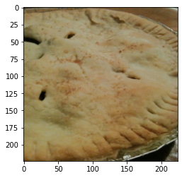

```python
# A test image
imshow(next(iter(test_loader))[0][1]);
```

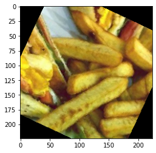

```python
# A training image
imshow(next(iter(train_loader))[0][1]);
# Look at the rotation from data augmentation!
```

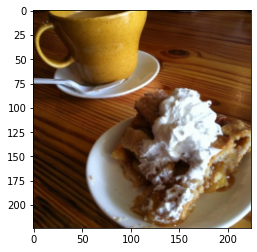

```python
# A validation image
imshow(next(iter(valid_loader))[0][1]);
```

That's basically it for this notebook! Now let's move on to the next notebook, where we will create a model and start training!